# Group by

- Visual Python: Data Analysis > Groupby
1. 기준 컬럼을 중심으로 그룹핑
2. 집계할 컬럼 선택
3. 선택된 컬럼의 집계 데이터(합계, 평균, 분산 등)를 각 그룹별로 산출

# Import python package

```python
# Visual Python: Data Analysis > Import
import numpy as np
import pandas as pd
import matplotlib.pyplot as plt
%matplotlib inline
import seaborn as sns
```

# Load files

```python
# Visual Python: Data Analysis > File
df_tips = pd.read_csv('./data/tips.csv')
df_tips
```

|  | total_bill | tip | smoker | day | time | size |
| --- | --- | --- | --- | --- | --- | --- |
| 0 | 16.99 | 1.01 | No | Sun | Dinner | 2 |
| 1 | 10.34 | 1.66 | No | Sun | Dinner | 3 |
| 2 | 21.01 | 3.50 | No | Sun | Dinner | 3 |
| 3 | 23.68 | 3.31 | No | Sun | Dinner | 2 |
| 4 | 24.59 | 3.61 | No | Sun | Dinner | 4 |
| ... | ... | ... | ... | ... | ... | ... |
| 239 | 29.03 | 5.92 | No | Sat | Dinner | 3 |
| 240 | 27.18 | 2.00 | Yes | Sat | Dinner | 2 |
| 241 | 22.67 | 2.00 | Yes | Sat | Dinner | 2 |
| 242 | 17.82 | 1.75 | No | Sat | Dinner | 2 |
| 243 | 18.78 | 3.00 | No | Thur | Dinner | 2 |

244 rows × 6 columns

```python
# Visual Python: Data Analysis > File
df_w = pd.read_csv('./data/washing_machine.csv')
df_w
```

|  | category_code | model_name | regist_country | create_dt_utc | device_id | event_type | State |
| --- | --- | --- | --- | --- | --- | --- | --- |
| 0 | 201 | LG_WM_KR | KR | 16/11/2017 0:22 | A1 | WM_STATE | 40 |
| 1 | 201 | LG_WM_KR | KR | 16/11/2017 0:32 | A1 | WM_STATE | 60 |
| 2 | 201 | LG_WM_KR | KR | 16/11/2017 0:32 | A1 | WM_WASH_END | 60 |
| 3 | 201 | LG_WM_KR | KR | 16/11/2017 2:48 | A1 | COMMON_WIFI_ON | 30 |
| 4 | 201 | LG_WM_KR | KR | 16/11/2017 2:57 | A1 | WM_STATE | 60 |
| ... | ... | ... | ... | ... | ... | ... | ... |
| 495 | 201 | LG_WM_KR | KR | 20/11/2017 10:18 | A5 | WM_STATE | 23 |
| 496 | 201 | LG_WM_KR | KR | 20/11/2017 11:19 | A5 | WM_STATE | 30 |
| 497 | 201 | LG_WM_KR | KR | 20/11/2017 11:56 | A5 | WM_STATE | 40 |
| 498 | 201 | LG_WM_KR | KR | 20/11/2017 12:04 | A5 | WM_STATE | 60 |
| 499 | 201 | LG_WM_KR | KR | 20/11/2017 12:04 | A5 | WM_WASH_END | 60 |

500 rows × 7 columns

# 1. Single aggregate function

## 1.1. Group by `day`, Agg. function: `mean()`

```python
# Visual Python: Data Analysis > Groupby
df_tips.groupby('day').mean(numeric_only=True)
```

| day | total_bill | tip | size |
| --- | --- | --- | --- |
| Fri | 17.151579 | 2.734737 | 2.105263 |
| Sat | 20.441379 | 2.993103 | 2.517241 |
| Sun | 21.410000 | 3.255132 | 2.842105 |
| Thur | 17.682742 | 2.771452 | 2.451613 |

## 1.2. Group by `day`, `smoker`, Agg. function: `mean()`

```python
# Visual Python: Data Analysis > Groupby
df_tips.groupby(['day','smoker']).mean(numeric_only=True)
```

| day | smoker | total_bill | tip | size |
| --- | --- | --- | --- | --- |
| Fri | No | 18.420000 | 2.812500 | 2.250000 |
|  | Yes | 16.813333 | 2.714000 | 2.066667 |
| Sat | No | 19.661778 | 3.102889 | 2.555556 |
|  | Yes | 21.276667 | 2.875476 | 2.476190 |
| Sun | No | 20.506667 | 3.167895 | 2.929825 |
|  | Yes | 24.120000 | 3.516842 | 2.578947 |
| Thur | No | 17.113111 | 2.673778 | 2.488889 |
|  | Yes | 19.190588 | 3.030000 | 2.352941 |

## 1.3. Group by `day`, Agg. column: `total_bill`, Agg. function: `mean()`

```python
# Visual Python: Data Analysis > Groupby
df_tips.groupby('day')['total_bill'].mean(numeric_only=True)
```

```
day
Fri     17.151579
Sat     20.441379
Sun     21.410000
Thur    17.682742
Name: total_bill, dtype: float64
```

## 1.4. Group by `day`, Agg. columns: `total_bill`, `tip`, Agg. function: `mean()`

```python
# Visual Python: Data Analysis > Groupby
df_tips.groupby('day')[['total_bill','tip']].mean(numeric_only=True)
```

| day | total_bill | tip |
| --- | --- | --- |
| Fri | 17.151579 | 2.734737 |
| Sat | 20.441379 | 2.993103 |
| Sun | 21.410000 | 3.255132 |
| Thur | 17.682742 | 2.771452 |

# 2. Multiple aggregate functions

## 2.1. Group by `day`, Agg. columns: `total_bill`, `tip`, Agg. functions: `std()`, `mean()`

```python
# Visual Python: Data Analysis > Groupby
df_tips.groupby('day')[['total_bill','tip']].agg(['std', 'mean'])
```

| day | total_bill std | total_bill mean | tip std | tip mean |
| --- | --- | --- | --- | --- |
| Fri | 8.302660 | 17.151579 | 1.019577 | 2.734737 |
| Sat | 9.480419 | 20.441379 | 1.631014 | 2.993103 |
| Sun | 8.832122 | 21.410000 | 1.234880 | 3.255132 |
| Thur | 7.886170 | 17.682742 | 1.240223 | 2.771452 |

## 2.2. Group by `day`, Agg. columns: `total_bill`, `tip`, Agg. functions: `std()`, `mean()`, Rename: `STD`, `AVG`

```python
# Visual Python: Data Analysis > Groupby
df_tips.groupby('day')[['total_bill','tip']].agg([('STD', 'std'), ('AVG', 'mean')])
```

| day | total_bill STD | total_bill AVG | tip STD | tip AVG |
| --- | --- | --- | --- | --- |
| Fri | 8.302660 | 17.151579 | 1.019577 | 2.734737 |
| Sat | 9.480419 | 20.441379 | 1.631014 | 2.993103 |
| Sun | 8.832122 | 21.410000 | 1.234880 | 3.255132 |
| Thur | 7.886170 | 17.682742 | 1.240223 | 2.771452 |

# 3. Multiple aggregate functions for each column

## 3.1. Group by `day`, Agg. columns: `total_bill`, `tip`, Agg. functions: `total_bill - sum()`, `tip - mean()`

```python
# Visual Python: Data Analysis > Groupby
df_tips.groupby('day')[['total_bill','tip']].agg({'total_bill': 'sum', 'tip': 'mean'})
```

| day | total_bill | tip |
| --- | --- | --- |
| Fri | 325.88 | 2.734737 |
| Sat | 1778.40 | 2.993103 |
| Sun | 1627.16 | 3.255132 |
| Thur | 1096.33 | 2.771452 |

## 3.2. Group by `day`, Agg. columns: `total_bill`, `tip`, Agg. functions: `total_bill - sum()`, `tip - std(), max(), mean(), median()`

```python
# Visual Python: Data Analysis > Groupby
df_tips.groupby('day')[['total_bill','tip']].agg({'total_bill': 'sum', 'tip': ['std','max','mean','median']})
```

| day | total_bill sum | tip std | tip max | tip mean | tip median |
| --- | --- | --- | --- | --- | --- |
| Fri | 325.88 | 1.019577 | 4.73 | 2.734737 | 3.000 |
| Sat | 1778.40 | 1.631014 | 10.00 | 2.993103 | 2.750 |
| Sun | 1627.16 | 1.234880 | 6.50 | 3.255132 | 3.150 |
| Thur | 1096.33 | 1.240223 | 6.70 | 2.771452 | 2.305 |

## 3.3. Group by `day`, Agg. columns: `total_bill`, `tip`, Agg. functions: `total_bill - sum()`, `tip - std(), mean()`, Rename: `SUM`, `STD`, `AVG`

```python
# Visual Python: Data Analysis > Groupby
df_tips.groupby('day')[['total_bill','tip']].agg({'total_bill': [('SUM', 'sum')], 'tip': [('STD', 'std'),('AVG', 'mean')]})
```

| day | total_bill SUM | tip STD | tip AVG |
| --- | --- | --- | --- |
| Fri | 325.88 | 1.019577 | 2.734737 |
| Sat | 1778.40 | 1.631014 | 2.993103 |
| Sun | 1627.16 | 1.234880 | 3.255132 |
| Thur | 1096.33 | 1.240223 | 2.771452 |

# 4. reset_index

`Check reset_index`

```python
# Visual Python: Data Analysis > Groupby
df_tips.groupby(['day','smoker'], as_index=False).mean(numeric_only=True)
```

|  | day | smoker | total_bill | tip | size |
| --- | --- | --- | --- | --- | --- |
| 0 | Fri | No | 18.420000 | 2.812500 | 2.250000 |
| 1 | Fri | Yes | 16.813333 | 2.714000 | 2.066667 |
| 2 | Sat | No | 19.661778 | 3.102889 | 2.555556 |
| 3 | Sat | Yes | 21.276667 | 2.875476 | 2.476190 |
| 4 | Sun | No | 20.506667 | 3.167895 | 2.929825 |
| 5 | Sun | Yes | 24.120000 | 3.516842 | 2.578947 |
| 6 | Thur | No | 17.113111 | 2.673778 | 2.488889 |
| 7 | Thur | Yes | 19.190588 | 3.030000 | 2.352941 |

```python
# Visual Python: Data Analysis > Groupby
df_tips.groupby('day', as_index=False)['tip'].mean(numeric_only=True)
```

|  | day | tip |
| --- | --- | --- |
| 0 | Fri | 2.734737 |
| 1 | Sat | 2.993103 |
| 2 | Sun | 3.255132 |
| 3 | Thur | 2.771452 |

# 5. Result: Series to DataFrame

`Check To DataFrame`

```python
# Visual Python: Data Analysis > Groupby
df_tips.groupby('day')[['tip']].mean(numeric_only=True)
```

| day | tip |
| --- | --- |
| Fri | 2.734737 |
| Sat | 2.993103 |
| Sun | 3.255132 |
| Thur | 2.771452 |

# 6. Grouper

### 6.1. As type(object --> datetime)

```python
# Visual Python: Data Analysis > Frame
df_w = df_w.astype({'create_dt_utc': 'datetime64[ns]'})
df_w
```

|  | category_code | model_name | regist_country | create_dt_utc | device_id | event_type | State |
| --- | --- | --- | --- | --- | --- | --- | --- |
| 0 | 201 | LG_WM_KR | KR | 2017-11-16 00:22:00 | A1 | WM_STATE | 40 |
| 1 | 201 | LG_WM_KR | KR | 2017-11-16 00:32:00 | A1 | WM_STATE | 60 |
| 2 | 201 | LG_WM_KR | KR | 2017-11-16 00:32:00 | A1 | WM_WASH_END | 60 |
| 3 | 201 | LG_WM_KR | KR | 2017-11-16 02:48:00 | A1 | COMMON_WIFI_ON | 30 |
| 4 | 201 | LG_WM_KR | KR | 2017-11-16 02:57:00 | A1 | WM_STATE | 60 |
| ... | ... | ... | ... | ... | ... | ... | ... |
| 495 | 201 | LG_WM_KR | KR | 2017-11-20 10:18:00 | A5 | WM_STATE | 23 |
| 496 | 201 | LG_WM_KR | KR | 2017-11-20 11:19:00 | A5 | WM_STATE | 30 |
| 497 | 201 | LG_WM_KR | KR | 2017-11-20 11:56:00 | A5 | WM_STATE | 40 |
| 498 | 201 | LG_WM_KR | KR | 2017-11-20 12:04:00 | A5 | WM_STATE | 60 |
| 499 | 201 | LG_WM_KR | KR | 2017-11-20 12:04:00 | A5 | WM_WASH_END | 60 |

500 rows × 7 columns

### 6.2. Group by `Grouper(create_dt_utc)`, Agg. function: `size`

```python
# Visual Python: Data Analysis > Groupby
df_count = df_w.groupby(pd.Grouper(key='create_dt_utc', freq='4H')).size()
df_count
```

```
create_dt_utc
2017-11-16 00:00:00    25
2017-11-16 04:00:00     7
2017-11-16 08:00:00    16
2017-11-16 12:00:00    31
2017-11-16 16:00:00     3
2017-11-16 20:00:00     8
2017-11-17 00:00:00    16
2017-11-17 04:00:00    14
2017-11-17 08:00:00    34
2017-11-17 12:00:00     7
2017-11-17 16:00:00     0
2017-11-17 20:00:00     0
2017-11-18 00:00:00    35
2017-11-18 04:00:00    16
2017-11-18 08:00:00    24
2017-11-18 12:00:00    26
2017-11-18 16:00:00     0
2017-11-18 20:00:00    15
2017-11-19 00:00:00    29
2017-11-19 04:00:00    39
2017-11-19 08:00:00    33
2017-11-19 12:00:00    19
2017-11-19 16:00:00     0
2017-11-19 20:00:00     4
2017-11-20 00:00:00    39
2017-11-20 04:00:00    23
2017-11-20 08:00:00    26
2017-11-20 12:00:00     7
2017-11-20 16:00:00     0
2017-11-20 20:00:00     4
Freq: 4H, dtype: int64
```

### 6.3. Bar chart

```python
# Visual Python: Visualization > Chart Style
import matplotlib.pyplot as plt
%matplotlib inline
import seaborn as sns
plt.rc('figure', figsize=(8, 6))

from matplotlib import rcParams
rcParams['font.size'] = 10
rcParams['axes.unicode_minus'] = False
```

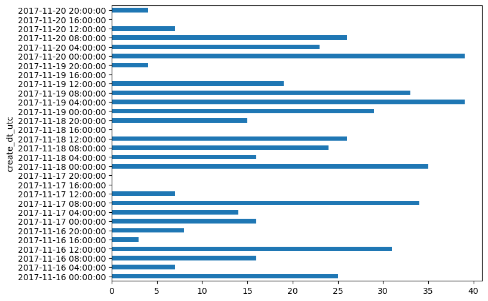

```python
# Visual Python: Library > Pandas Plot
df_count.plot(kind='barh')
plt.show()
```

# [실습] 직접 해보기

## 실습 1. tips 데이터로 복습하기

```python
# Visual Python: Data Analysis > File
tips = pd.read_csv('./data/tips.csv')
tips
```

|  | total_bill | tip | smoker | day | time | size |
| --- | --- | --- | --- | --- | --- | --- |
| 0 | 16.99 | 1.01 | No | Sun | Dinner | 2 |
| 1 | 10.34 | 1.66 | No | Sun | Dinner | 3 |
| 2 | 21.01 | 3.50 | No | Sun | Dinner | 3 |
| 3 | 23.68 | 3.31 | No | Sun | Dinner | 2 |
| 4 | 24.59 | 3.61 | No | Sun | Dinner | 4 |
| ... | ... | ... | ... | ... | ... | ... |
| 239 | 29.03 | 5.92 | No | Sat | Dinner | 3 |
| 240 | 27.18 | 2.00 | Yes | Sat | Dinner | 2 |
| 241 | 22.67 | 2.00 | Yes | Sat | Dinner | 2 |
| 242 | 17.82 | 1.75 | No | Sat | Dinner | 2 |
| 243 | 18.78 | 3.00 | No | Thur | Dinner | 2 |

244 rows × 6 columns

#### Q. tips 데이터의 기준 컬럼을 'time'으로 'total_bill'과 'tip'의 sum을 각각 구하세요.

```python
tips.groupby('time')[['total_bill','tip']].sum(numeric_only=True)
```

| time | total_bill | tip |
| --- | --- | --- |
| Dinner | 3660.30 | 546.07 |
| Lunch | 1167.47 | 185.51 |

#### Q. tips 데이터의 기준 컬럼을 'time'으로 'total_bill'과 'tip'의 sum, mean을 각각 구하고 컬럼 이름을 '합계', '평균'으로 설정하세요.

```python
tips.groupby('time')[['total_bill','tip']].agg([('합계', 'sum'), ('평균', 'mean')])
```

| time | total_bill 합계 | total_bill 평균 | tip 합계 | tip 평균 |
| --- | --- | --- | --- | --- |
| Dinner | 3660.30 | 20.797159 | 546.07 | 3.102670 |
| Lunch | 1167.47 | 17.168676 | 185.51 | 2.728088 |

#### Q. tips 데이터의 기준 컬럼을 'time'으로 'total_bill의 sum'과 'tip'의 sum, mean을 각각 구하고 컬럼 이름을 '합계', '평균'으로 설정하세요.

```python
tips.groupby('time')[['total_bill','tip']].agg({'total_bill': [('합계', 'sum')], 'tip': [('합계', 'sum'),('평균', 'mean')]})
```

| time | total_bill 합계 | tip 합계 | tip 평균 |
| --- | --- | --- | --- |
| Dinner | 3660.30 | 546.07 | 3.102670 |
| Lunch | 1167.47 | 185.51 | 2.728088 |

#### Q. df 데이터의 기준 컬럼을 'create_dt_utc'의 하루(1day) 단위로 설정하고 각 행의 수(size)를 출력하세요.

```python
df_w.groupby(pd.Grouper(key='create_dt_utc', freq='1D')).size()
```

```
create_dt_utc
2017-11-16     90
2017-11-17     71
2017-11-18    116
2017-11-19    124
2017-11-20     99
Freq: D, dtype: int64
```

## 실습 2. titanic 데이터로 집계하기

```python
# Visual Python: Data Analysis > File
df_titanic = pd.read_csv('./data/titanic.csv')
df_titanic
```

|  | PassengerId | Survived | Pclass | Name | Sex | Age | SibSp | Parch | Ticket | Fare | Cabin | Embarked |
| --- | --- | --- | --- | --- | --- | --- | --- | --- | --- | --- | --- | --- |
| 0 | 1 | 0 | 3 | Braund, Mr. Owen Harris | male | 22.0 | 1 | 0 | A/5 21171 | 7.2500 | NaN | S |
| 1 | 2 | 1 | 1 | Cumings, Mrs. John Bradley (Florence Briggs Th... | female | 38.0 | 1 | 0 | PC 17599 | 71.2833 | C85 | C |
| 2 | 3 | 1 | 3 | Heikkinen, Miss. Laina | female | 26.0 | 0 | 0 | STON/O2. 3101282 | 7.9250 | NaN | S |
| 3 | 4 | 1 | 1 | Futrelle, Mrs. Jacques Heath (Lily May Peel) | female | 35.0 | 1 | 0 | 113803 | 53.1000 | C123 | S |
| 4 | 5 | 0 | 3 | Allen, Mr. William Henry | male | 35.0 | 0 | 0 | 373450 | 8.0500 | NaN | S |
| ... | ... | ... | ... | ... | ... | ... | ... | ... | ... | ... | ... | ... |
| 886 | 887 | 0 | 2 | Montvila, Rev. Juozas | male | 27.0 | 0 | 0 | 211536 | 13.0000 | NaN | S |
| 887 | 888 | 1 | 1 | Graham, Miss. Margaret Edith | female | 19.0 | 0 | 0 | 112053 | 30.0000 | B42 | S |
| 888 | 889 | 0 | 3 | Johnston, Miss. Catherine Helen "Carrie" | female | NaN | 1 | 2 | W./C. 6607 | 23.4500 | NaN | S |
| 889 | 890 | 1 | 1 | Behr, Mr. Karl Howell | male | 26.0 | 0 | 0 | 111369 | 30.0000 | C148 | C |
| 890 | 891 | 0 | 3 | Dooley, Mr. Patrick | male | 32.0 | 0 | 0 | 370376 | 7.7500 | NaN | Q |

891 rows × 12 columns

#### Q. 기준 컬럼을 `Pclass`로 `Age`와 `Fare`컬럼의 평균값을 구하세요.

```python
# Visual Python: Data Analysis > Groupby
df_titanic.groupby('Pclass')[['Age','Fare']].mean(numeric_only=True)
```

| Pclass | Age | Fare |
| --- | --- | --- |
| 1 | 38.233441 | 84.154687 |
| 2 | 29.877630 | 20.662183 |
| 3 | 25.140620 | 13.675550 |

#### Q. 기준 컬럼을 `Survived`로 `Age`와 `Pclass`, `Fare` 컬럼의 평균과 중앙값을 구하세요.

```python
# Visual Python: Data Analysis > Groupby
df_titanic.groupby('Survived')[['Pclass','Age','Fare']].agg(['mean', 'median'])
```

| Survived | Pclass mean | Pclass median | Age mean | Age median | Fare mean | Fare median |
| --- | --- | --- | --- | --- | --- | --- |
| 0 | 2.531876 | 3.0 | 30.626179 | 28.0 | 22.117887 | 10.5 |
| 1 | 1.950292 | 2.0 | 28.343690 | 28.0 | 48.395408 | 26.0 |

#### Q. 기준 컬럼을 `Survived`와 `Pclass`로, `Age` 컬럼의 min, max, mean을 구하고 `Fare` 컬럼의 mean, sum, quantile을 구하세요.

```python
# Visual Python: Data Analysis > Groupby
df_titanic.groupby(['Survived','Pclass']).agg({'Age': ['max','mean','min'], 'Fare': ['sum','mean','quantile']})
```

| Survived | Pclass | Age max | Age mean | Age min | Fare sum | Fare mean | Fare quantile |
| --- | --- | --- | --- | --- | --- | --- | --- |
| 0 | 1 | 71.0 | 43.695312 | 2.00 | 5174.7206 | 64.684007 | 44.7500 |
|  | 2 | 70.0 | 33.544444 | 16.00 | 1882.9958 | 19.412328 | 13.0000 |
|  | 3 | 74.0 | 26.555556 | 1.00 | 5085.0035 | 13.669364 | 8.0500 |
| 1 | 1 | 80.0 | 35.368197 | 0.92 | 13002.6919 | 95.608029 | 77.9583 |
|  | 2 | 62.0 | 25.901566 | 0.67 | 1918.8459 | 22.055700 | 21.0000 |
|  | 3 | 63.0 | 20.646118 | 0.42 | 1629.6916 | 13.694887 | 8.5167 |

#### Q. 기준 컬럼을 `Survived`와 `Pclass`로, `Age` 컬럼의 min, max, mean을 구하고, 각각 최소나이, 최대나이, 평균나이로 컬럼명을 지정해 출력하세요.

```python
# Visual Python: Data Analysis > Groupby
df_titanic.groupby(['Survived','Pclass']).agg({'Age': [('최대나이', 'max'),('평균나이', 'mean'),('최소나이', 'min')]})
```

| Survived | Pclass | Age 최대나이 | Age 평균나이 | Age 최소나이 |
| --- | --- | --- | --- | --- |
| 0 | 1 | 71.0 | 43.695312 | 2.00 |
|  | 2 | 70.0 | 33.544444 | 16.00 |
|  | 3 | 74.0 | 26.555556 | 1.00 |
| 1 | 1 | 80.0 | 35.368197 | 0.92 |
|  | 2 | 62.0 | 25.901566 | 0.67 |
|  | 3 | 63.0 | 20.646118 | 0.42 |

```python
# End of file
```